# MSEA

BangzhuoTong

2022/7/20

# MSEA

This is a markdown tutorial for MSEA. To run MSEA, you need to Install MSEA to your default python before running this template. Installation instruction: https://msea.readthedocs.io/en/latest/quickstart.html#installation.

You can run MSEA when you got genus that you’re interested in (e.g., DA genus), write all genus into one txt file, one genus per line and feed the file to MSEA as input.

## Execute MSEA with python script on server

You can run MSEA analysis with MSEA_Run.py on server, one required parameters and two optional parameters need to be provided for the script:

1. –input (Required), input genus list file for MSEA, one genus per line.
2. –output (Optional), output csv file of MSEA result. Default testout.csv
3. –PerturbationTimes (Optional), number of perturbation. Fisher’s excat test has bias on group with large number of samples, MSEA uses random sampling to remove the bias. Larger number of perturbation would cause longer runtime. Default 50.  
   For more drtail, see *[citation](https://www.nature.com/articles/s41598-020-78511-y)*

```bash
/home/tongbangzhuo/Software/miniconda3/bin/python /share/projects/SOP/Functional_Analysis/Tongbangzhuo/MSEA/MSEA_Run.py --input test_input --output testout.csv --PerturbationTimes 10
```

```
##
## Reading database file
##
## Calculating empirical ranks for each set...
## Number of unique microbes: 566
##
##
## Performing MSEA with adjustment
##
## Showing the head of result table:
##          oddsratio  ...  n_shared
## term                ...
## IFNAR1   53.333333  ...         4
## HPRT1    42.857143  ...         3
## TRADD    72.727273  ...         4
## FOLH1   160.000000  ...         4
## IL10      9.009009  ...         5
##
## [5 rows x 7 columns]
##
## Finished !!
```

## Read in MSEA result

```r
library(dplyr)
```

```r
library(magrittr)
library(ggplot2)
library(ggbipart)
library(stringr)
library(tibble)
library(wesanderson)

MSEA_res = read.csv('/share/projects/SOP/Functional_Analysis/Tongbangzhuo/MSEA/testout.csv', sep = '\t')
head(MSEA_res, n=3)
```

```
##     term oddsratio       pvalue       qvalue     zscore combined_score
## 1 IFNAR1  53.33333 1.010645e-05 1.312818e-04  -8.647990       99.47209
## 2  HPRT1  42.85714 2.038337e-04 6.755933e-04 -11.689430       99.33918
## 3  TRADD  72.72727 3.672520e-06 9.082424e-05  -7.351898       92.00630
##                                                 shared n_shared
## 1 ['Salmonella', 'Borrelia', 'Pseudomonas', 'Sodalis']        4
## 2                ['Salmonella', 'Borrelia', 'Sodalis']        3
## 3 ['Salmonella', 'Pseudomonas', 'Azomonas', 'Sodalis']        4
```

## Filter and Visualize MSEA result

```r
## Filter MSEA result with qvalue
MSEA_res %<>% filter(qvalue < 0.05)


## Draw bipartite with top 10 combined_score human genes

## Define data transforming function
Transform_data <- function(df){
  All_Genus_in_res <- df$shared %>% unlist() %>% str_remove_all('\\[') %>% str_remove_all('\\]') %>% str_remove_all("'") %>% str_split(', ') %>% unlist() %>% unique()
  lst <- list()
  for (i in All_Genus_in_res){
    count_vec <- c()
    for (j in (1:nrow(df))){
      target_string = df[j,'shared']  %>% str_remove_all('\\[') %>% str_remove_all('\\]') %>% str_remove_all("'") %>% str_split(', ') %>% unlist()
      count = sum(i == target_string)
      count_vec <- c(count_vec, count)
    }
    lst[[i]] <- count_vec
  }
  bipartite_tbl <- cbind(Top_MSEA_res, as.data.frame(lst)) %>% select(term, all_of(All_Genus_in_res)) %>% column_to_rownames('term')
  return(bipartite_tbl)
}

## Select top 10 human genes
Top_MSEA_res <- MSEA_res[1:10,]
```

## Draw bipartit graph to show the relation between human genes and microbial Genus with ggnet.

```r
## Generate data for bipartit graph
bipartite_tbl <- Transform_data(Top_MSEA_res)

## Define network layout
mymat <- bipartite_tbl
coordP <- cbind(rep(2, dim(mymat)[1]), seq(1, dim(mymat)[1]) +
        2)
coordA <- cbind(rep(4, dim(mymat)[2]), seq(1, dim(mymat)[2]) +
        2)

mylayout <- as.matrix(rbind(coordP, coordA))

## Construct network content
test.net <- bip_init_network(mymat, mode1 = 'HumanGenes',mode2 = 'MicrobialGenus')
```

[output not shown]

```r
# Define groups of network nodes
test.net %v% "Group" = get.vertex.attribute(test.net, attrname="mode")

# Draw network
p <- GGally::ggnet2(test.net, mode = mylayout,
               label = T, size = "degree",
               color = 'Group', shape = 'Group',
               label.size = 5, layout.exp = 1.5, alpha = 0.75) +
  scale_colour_manual(values = wes_palette("FantasticFox1")) +
  guides(color=guide_legend("Group"))
```

[output not shown]

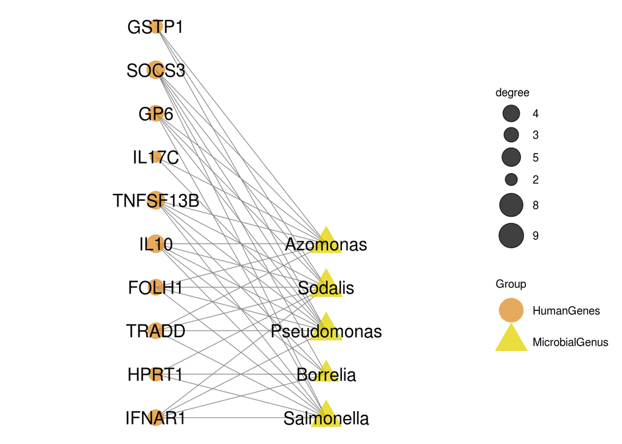

```r
p
```

## Run enrichR analysis

After acquiring genus-associated human genes, you can run enrich your genes on different databases by enrichR.  
The next chunk shows you how to run enrichR on R studio, you can either run enrichR on their interactive *[website](https://maayanlab.cloud/Enrichr/)*.

```r
library(enrichR)
## List available types of databases
listEnrichrSites()
```

```
## Enrichr ... Connection is Live!
## FlyEnrichr ... Connection is available!
## WormEnrichr ... Connection is available!
## YeastEnrichr ... Connection is available!
## FishEnrichr ... Connection is available!
```

```r
## Choose database of Human genes
setEnrichrSite("Enrichr")
```

```
## Connection changed to https://maayanlab.cloud/Enrichr/
## Connection is Live!
```

```r
## List available database
websiteLive <- TRUE
dbs <- listEnrichrDbs()
if (is.null(dbs)) websiteLive <- FALSE
if (websiteLive) head(dbs)
```

```
##   geneCoverage genesPerTerm                      libraryName
## 1        13362          275              Genome_Browser_PWMs
## 2        27884         1284         TRANSFAC_and_JASPAR_PWMs
## 3         6002           77        Transcription_Factor_PPIs
## 4        47172         1370                        ChEA_2013
## 5        47107          509 Drug_Perturbations_from_GEO_2014
## 6        21493         3713          ENCODE_TF_ChIP-seq_2014
##                                                       link numTerms
## 1 http://hgdownload.cse.ucsc.edu/goldenPath/hg18/database/      615
## 2                 http://jaspar.genereg.net/html/DOWNLOAD/      326
## 3                                                               290
## 4           http://amp.pharm.mssm.edu/lib/cheadownload.jsp      353
## 5                         http://www.ncbi.nlm.nih.gov/geo/      701
## 6             http://genome.ucsc.edu/ENCODE/downloads.html      498
##                                    appyter categoryId
## 1 ea115789fcbf12797fd692cec6df0ab4dbc79c6a          1
## 2 7d42eb43a64a4e3b20d721fc7148f685b53b6b30          1
## 3 849f222220618e2599d925b6b51868cf1dab3763          1
## 4 7ebe772afb55b63b41b79dd8d06ea0fdd9fa2630          7
## 5 ad270a6876534b7cb063e004289dcd4d3164f342          7
## 6 497787ebc418d308045efb63b8586f10c526af51          7
```

```r
## Choose the databases you want to enrich your genes with and Run enrichR of genus-associated human genes on chosen databases
dbs <- c("GO_Molecular_Function_2021","KEGG_2019_Human")
if (websiteLive) {
    enriched <- enrichr(MSEA_res$term %>% as.vector(), dbs)
}
```

```
## Uploading data to Enrichr... Done.
##   Querying GO_Molecular_Function_2021... Done.
##   Querying KEGG_2019_Human... Done.
## Parsing results... Done.
```

```r
## Show first few rows of enrichment result
Kegg_res <- enriched[['KEGG_2019_Human']]
head(Kegg_res)
```

```
##                                              Term Overlap      P.value
## 1                              Pathways in cancer 118/530 3.368482e-53
## 2          Cytokine-cytokine receptor interaction  90/294 4.368984e-53
## 3                         IL-17 signaling pathway   52/93 2.802254e-47
## 4                                     Hepatitis B  63/163 2.226240e-44
## 5 Kaposi sarcoma-associated herpesvirus infection  66/186 1.153286e-43
## 6                                     Hepatitis C  61/155 1.497013e-43
##   Adjusted.P.value Old.P.value Old.Adjusted.P.value Odds.Ratio Combined.Score
## 1     6.029198e-51           0                    0   7.523619       909.0228
## 2     6.029198e-51           0                    0  11.275567      1359.4103
## 3     2.578073e-45           0                    0  31.100813      3333.7296
## 4     1.536105e-42           0                    0  15.621378      1570.1583
## 5     6.366139e-42           0                    0  13.676762      1352.2016
## 6     6.886260e-42           0                    0  16.054226      1583.0701
##                                                                                                                                                                                                                                                                                                          …
## 1 SPI1;EPO;ARAF;KEAP1;FGF2;CRKL;FGF7;CCND1;CDH1;MYC;AKT2;AKT1;SKP1;MAP2K1;HGF;WNT5A;MITF;PGF;RUNX1;TP53;IFNAR1;NOTCH1;PDGFB;HIF1A;BCL2L11;TERT;ABL1;HMOX1;PMAIP1;FADD;SMAD2;TGFB2;SMAD4;GSTM1;TGFB1;SMAD3;TGFB3;WNT3A;NFKB1;PTK2;IL2;IL4;NFKBIA;BMP4;BMP2;IL6;CXCL12;CDK6;CDK4;CDK2;GNAS;GRB2;FGFR2;BCL2L…
## 2                                                                                                                                                 IL21;CXCL6;IL1RN;CD40;CSF3;CXCL9;CSF2;EDA;CXCL8;EPO;FASLG;CXCL1;PRL;CXCL13;CXCL3;TNF;CXCL2;CX3CL1;CXCL5;TNFSF13B;CCR9;TNFSF11;CCR7;CCR5;AMH;CCR3;CCR2;I…
## 3                                                                                                                                                                                                                                                                                                        …
## 4                                                                                                                                                                                                                                                                                                        …
## 5                                                                                                                                                                                                                                                                                              CD86;CDKN1…
## 6                                                                                                                                                                                                                                                                                                        …
```

```r
GO_res <- enriched[['GO_Molecular_Function_2021']]
head(GO_res)
```

```
##                                      Term Overlap      P.value Adjusted.P.value
## 1          cytokine activity (GO:0005125)  61/173 3.155810e-40     2.098614e-37
## 2   receptor ligand activity (GO:0048018)  69/307 1.967964e-31     6.543481e-29
## 3 chemokine receptor binding (GO:0042379)   27/50 1.496174e-24     3.316519e-22
## 4         chemokine activity (GO:0008009)   26/46 2.168043e-24     3.604371e-22
## 5  cytokine receptor binding (GO:0005126)  34/105 1.501517e-21     1.997018e-19
## 6             kinase binding (GO:0019900)  70/461 3.129734e-21     3.468788e-19
##   Old.P.value Old.Adjusted.P.value Odds.Ratio Combined.Score
## 1           0                    0  13.461367      1224.3673
## 2           0                    0   7.192804       508.5538
## 3           0                    0  27.918715      1531.5964
## 4           0                    0  30.883871      1682.8071
## 5           0                    0  11.459953       549.4796
## 6           0                    0   4.411563       208.2846
##                                                                                                                                                                                                                                                                                                          …
## 1                                            CXCL6;CSF3;CXCL9;CSF2;CXCL8;EPO;CXCL1;HMGB1;CXCL13;CXCL3;FGF2;TNF;CXCL2;CX3CL1;CXCL5;TNFSF11;TIMP1;IL10;IL11;IL15;ADIPOQ;WNT5A;IL18;NRG1;MIF;IL1A;IFNG;IL1B;CCL13;CCL11;TNFRSF11B;CCL7;CCL2;CCL1;CCL19;CCL17;CCL25;IL33;TGFB2;TGFB1;CCL22;TSLP;CCL21;TGFB3;W…
## 2                          CSF3;CXCL9;CSF2;EDA;EPO;CXCL1;PRL;HMGB1;CXCL13;FGF2;TNF;CX3CL1;TNFSF13B;LGALS3;FGF7;TNFSF11;TIMP1;AMH;IL10;IL11;IL15;HGF;ADIPOQ;WNT5A;IL18;APOA1;NRG1;MIF;NGF;PGF;BTC;IL1A;IFNG;IL1B;DEFB4A;HBEGF;CCL11;PTH;PDGFB;TNFRSF11B;PTN;NTS;INS;NPY;PPY;CCL25;IL33;TGFB2;TGFB1;TSLP;BD…
## 3                                                                                                                                                                                                                               CX3CR1;CXCL6;CCL13;CXCL9;CXCL8;CCL11;CXCL1;CXCL13;CXCL3;CXCL2;CX3CL1;CXCL…
## 4                                                                                                                                                                                                                                      CCL13;CXCL6;CXCL9;CCL11;CXCL8;CXCL1;CXCL13;CXCL3;CXCL2;CX3CL1;CXCL…
## 5                                                                                                                                                                                                             IL21;CSF3;IL1RN;EPO;PRL;PYCARD;TNFSF11;FADD;CCL19;JAK2;IL12RB1;SMAD2;IL10;CCL25;IL11;TGFB2;…
## 6 CDKN1A;TFRC;TRADD;HSPB1;ILK;PARK7;FOXM1;IKBKB;CASP9;CCND1;RAC2;CASP1;JAK2;CHIA;PARP1;RPS6;RHOG;ADAM10;IRAK3;IRAK4;RHOC;CDC25A;RHOA;RHOB;CCNA2;FGR;CEACAM1;TRAF6;VDAC1;MAPT;SQSTM1;CRK;TP53;ATF4;BECN1;CEBPA;SRC;MVP;PLG;IQGAP1;NOD2;PTN;FOXO3;HIF1A;EGFR;RELA;TTN;RELB;CDC42;CCNB1;SOCS1;IRAK1;RPS3;PTP…
```

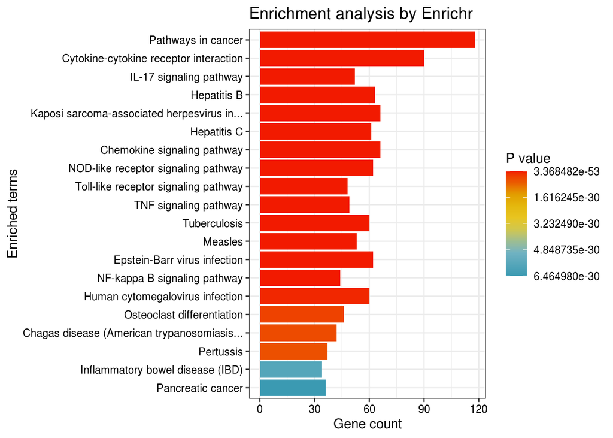

```r
## Plot Enrichment result
plotEnrich(enriched[['KEGG_2019_Human']] %>% filter(Adjusted.P.value < 0.05),
           showTerms = 20, numChar = 40, y = "Count", orderBy = "P.value") +
  scale_fill_gradientn(colours = rev(wes_palette("Zissou1", 10, type = "continuous")))
```

As shown above, Y axis shows the enriched terms of your input genes. X axis shows the number of input genes in the enriched terms.